# Pantaleo - Exploratory Analysis - TFH146

Valentin Voillet

# Contents

*File creation: June, 19th 2017*  
*Update: June, 19th 2017*

# 1 Data Loading & Description

Briefly, paired PBMCs (Peripheral blood mononuclear cells) and LN (Lymph Node) from patients were stained and sorted for TFH (T Follicular Helper) and Live cells. There are three HIV+ CP off treatment and three HIV- patients.

Per patient, per sample, two Seq-Well arrays were processed. *NB: each patient has the following processed array conditions: LN TFH, LN Live, PBMC TFH, & PBMC Live.*

Here - we have four arrays from one HIV- CP patient.

**Obj: Re-perform the analysis // Look at the data.**

# 2 Live Cells

## 2.1 Raw Count

Let’s look at the distribution of UMIs and nb. of detected genes in both LN and PBMC samples for Live Cells.

*NB: We do not have information about read distribution.*

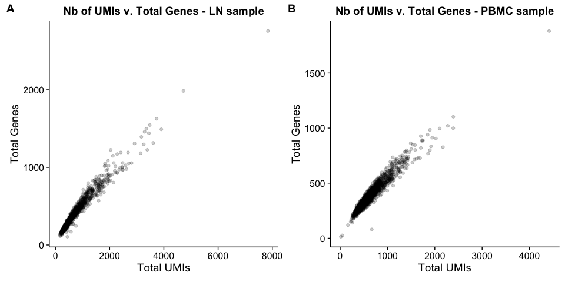

It seems to exhibit a quite proportional capture efficient here, whereas current platforms (DropSeq, etc.) usually exhibit low and highly variable capture efficiency.

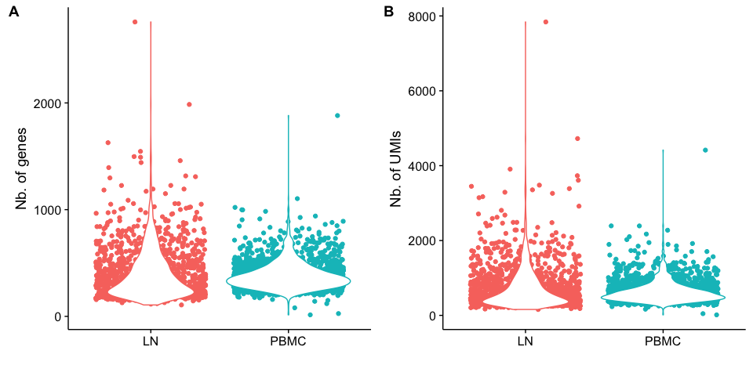

Close nb. of UMIs and detected genes are observed in bith LN and PBMC samples from Live Cells.

## 2.2 QC and Filtering

The next step is then to perform quality control and filtering (remove cells with few reads/UMIs or genes, etc.).

The threshold that Sam used was **750 UMIs** and **400 genes** (see *Slides for Pantaleo 053017.ppt* file - HIV+ patient). So, let’s use the same here, and also remove genes with less than one UMI count.

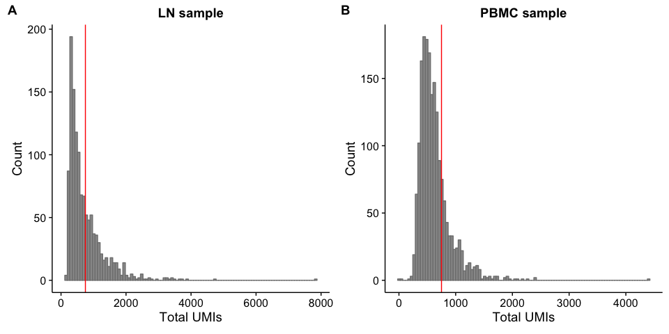

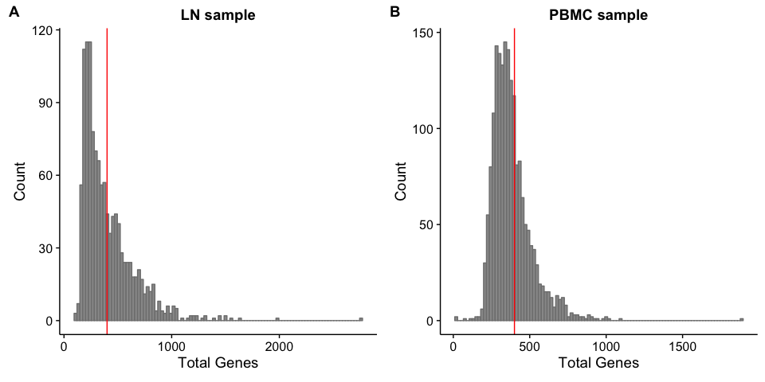

```r
###--- Filtering datasets and merging
#- LN
identical(colnames(LiveCells_LN_UMI), rownames(LiveCells_LN_UMI_summary)) # TRUE
LiveCells_LN_UMI_filtered <- LiveCells_LN_UMI[, which(LiveCells_LN_UMI_summary$NUM_GENES >= 400 & LiveCells_LN_UMI_summary$NUM_TRANSCRIPTS >= 750)] # 417 cells
LiveCells_LN_UMI_filtered <- LiveCells_LN_UMI_filtered[which(apply(LiveCells_LN_UMI_filtered, 1, sum) != 0), ] # 14,946 genes and 417 cells
#- PBMC
identical(colnames(LiveCells_PBMC_UMI), rownames(LiveCells_PBMC_UMI_summary)) # TRUE
LiveCells_PBMC_UMI_filtered <- LiveCells_PBMC_UMI[, which(LiveCells_PBMC_UMI_summary$NUM_GENES >= 400 & LiveCells_PBMC_UMI_summary$NUM_TRANSCRIPTS >= 750)] # 409 cells
LiveCells_PBMC_UMI_filtered <- LiveCells_PBMC_UMI_filtered[which(apply(LiveCells_PBMC_UMI_filtered, 1, sum) != 0), ] # 12,391 genes and 409 cells
#- Merging
LiveCells_UMI <- rbind.fill(as.data.frame(t(LiveCells_LN_UMI_filtered)), as.data.frame(t(LiveCells_PBMC_UMI_filtered)))
rownames(LiveCells_UMI) <- c(paste(colnames(LiveCells_LN_UMI_filtered), 'LN', sep = '_'), paste(colnames(LiveCells_PBMC_UMI_filtered), 'PBMC', sep = '_'))
dim(LiveCells_UMI) # 826 cells and 16,230 genes
length(unique(c(rownames(LiveCells_LN_UMI_filtered), rownames(LiveCells_PBMC_UMI_filtered)))) # 16,230 genes
LiveCells_UMI[is.na(LiveCells_UMI)] <- 0 # NAs - replace NA by 0
LiveCells_UMI <- as.data.frame(t(LiveCells_UMI))
```

After filtering, we have:

- **14,946 genes** and **417 cells** - LN sample
- **12,391 genes** and **409 cells** - PBMC sample

After merging those two datasets together, we have:

- **826 cells** and **16,230 genes**

One thing is obvious here - we do have less cells and genes in this Live Cells HIV- sample than in HIV+.

## 2.3 Normalization

As in Gierahn et al. (2017), for each cell, we performed library-size normalization. UMI-collapsed gene expression values for each cell barcode were scaled by the total number of transcripts and multiplied by 10,000. Scaled expression data were then natural-log transformed before analysis using Seurat. *NB: Scaling and log2-transformation actually done with Seurat.*

## 2.4 Seurat Analysis

Seurat analysis using the normalized dataset. It includes the removing of unwanted sources of variation, PCA, clustering and tSNE. All analyses are done as in Gierhan et al. (2017).

The single cell dataset likely contains *uninteresting* sources of variation. This could include not only technical noise, but batch effects, or even biological sources of variation (cell cycle stage). As suggested in Buettner et al. (2015), regressing these signals out of the analysis can improve downstream dimensionality reduction and clustering. Seurat implements a basic version of this by constructing linear models to predict gene expression based on user-defined variables. Seurat stores the z-scored residuals of these models in the scale.data slot, and they are used for dimensionality reduction and clustering. We typically regress out cell-cell variation in gene expression driven by batch (if applicable), cell alignment rate (as provided by Drop-seq tools for Drop-seq data), the number of detected molecules and mitochondrial gene expression. For cycling cells, we can also learn a cell-cycle score (as in Macosko et al. (2015)) and Regress this out as well - from Gierhan et al. (2017).  
Here, we simply regress on the number of detected molecules per cell as well as the percentage mitochondrial gene content.

```r
###--- Regress out unwanted sources of variation
mito.genes <- grep("^MT-", rownames(seuratObj_LiveCells_global@data), value = TRUE)
percent.mito <- colSums(as.matrix(expm1(seuratObj_LiveCells_global@data[mito.genes, ]))) / colSums(as.matrix(expm1(seuratObj_LiveCells_global@data)))
seuratObj_LiveCells_global <- AddMetaData(seuratObj_LiveCells_global, percent.mito, 'percent.mito')
GenePlot(seuratObj_LiveCells_global, 'nUMI', 'percent.mito')
GenePlot(seuratObj_LiveCells_global, 'nUMI', 'nGene')
#- remove unwanted sources of variation
seuratObj_LiveCells_global <- RegressOut(seuratObj_LiveCells_global, latent.vars = c('nUMI', 'percent.mito')) # remove effect of CDR (high correlation between nGene and nUMI - 0.96) and mitochondrial
```

After, Seurat calculates highly variable genes and focuses on these for downstream analysis.

```r
###--- Detection of variable genes across the single cells
seuratObj_LiveCells_global <- MeanVarPlot(seuratObj_LiveCells_global, fxn.x = expMean, fxn.y = logVarDivMean, x.low.cutoff = 0.1, x.high.cutoff = 3, y.cutoff = 0.5, do.contour = FALSE)
length(seuratObj_LiveCells_global@var.genes) # 1,911 highly variable genes
```

We identified 1,911 variable genes with log-mean expression values greater than 0.1 and dispersion (variance/mean) greater than 0.5.

```r
###--- PCA
#- PCA performed on the scaled data and using only highly variable genes - with correction
seuratObj_LiveCells_global <- PCA(seuratObj_LiveCells_global, pc.genes = seuratObj_LiveCells_global@var.genes)
seuratObj_LiveCells_global <- ProjectPCA(seuratObj_LiveCells_global)
```

We can identify markers that are strongly correlated with cellular heterogeneity - see below.

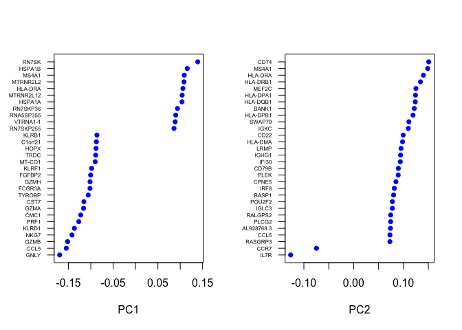

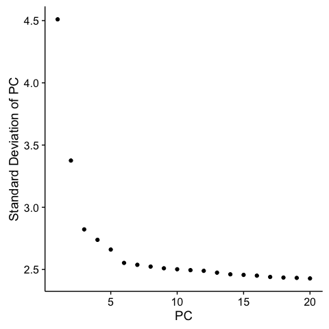

```r
###--- tSNE
seuratObj_LiveCells_global <- RunTSNE(seuratObj_LiveCells_global, dims.use = 1:6, perplexity = 50)
```

Let’s look at the tSNE plots now - perplexity of 50 and 1,000 iterations.

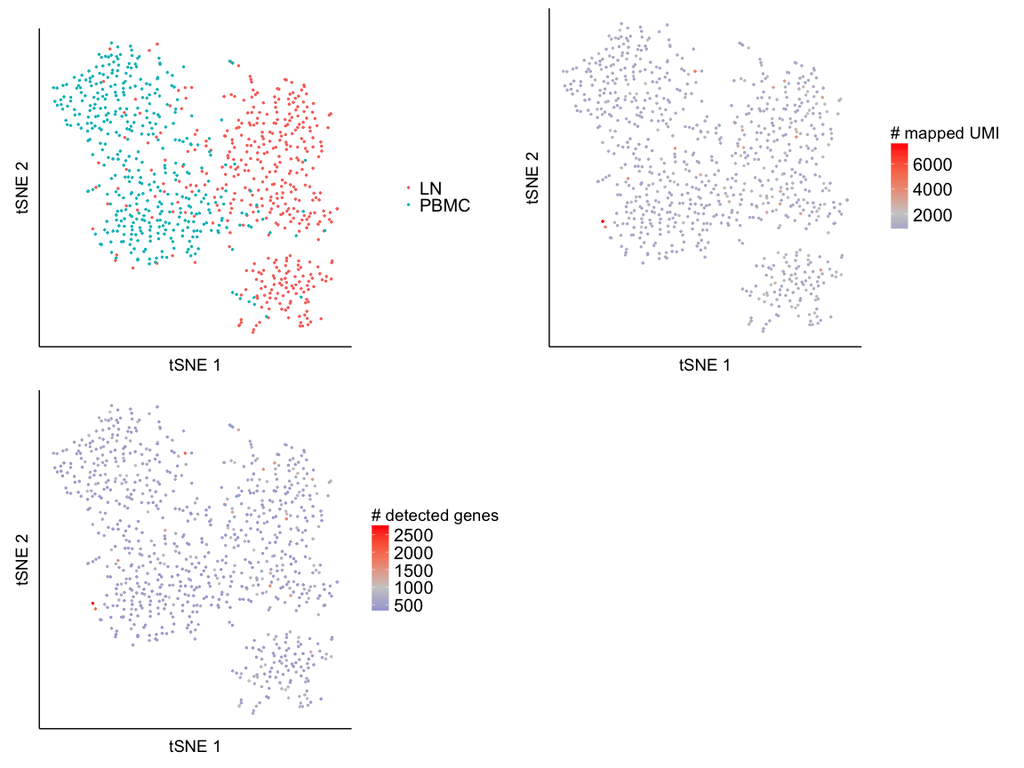

We do see a differences between LN and PBMC samples from Live Cells. As explained in the email, we also observe a small cluster composed of B cells, but only B cells from LN sample.

Let’s look at different markers now.

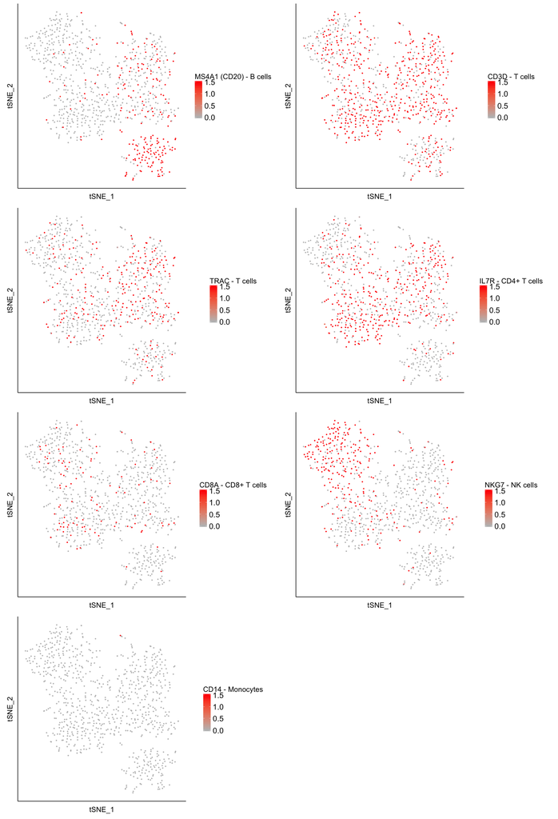

We do observe B cells, T cells and NK cells. As suggested by Sam, B cells only expressed in LN sample. Q. Is it really a issue here?

```r
###--- Clustering
seuratObj_LiveCells_global <- FindClusters(seuratObj_LiveCells_global, pc.use = 1:6, resolution = 0.60, print.output = 0, k.param = 30, save.SNN = FALSE)
```

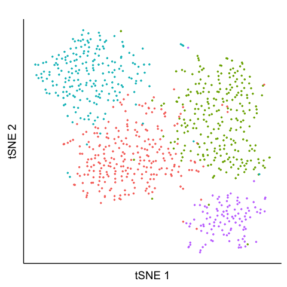

We do see four clusters: B cells, NK cells and two clusters of T cells (from LN or from PBMC). We cannot go deeper here.

# 3 TFH Cells

Follicular helper T (Tfh) cells are a distinct subset of CD4+ helper T (Th) cells that regulate the development of antigen-specific B cell immunity.

Here - look at the two TFH arrays (from PBMC and LN) - sorted PD-1+ CXCR5+ and ICOS+.

## 3.1 Raw Count

Let’s look at the distribution of UMIs, reads and nb. of detected genes in both LN and PBMC samples for Live Cells.

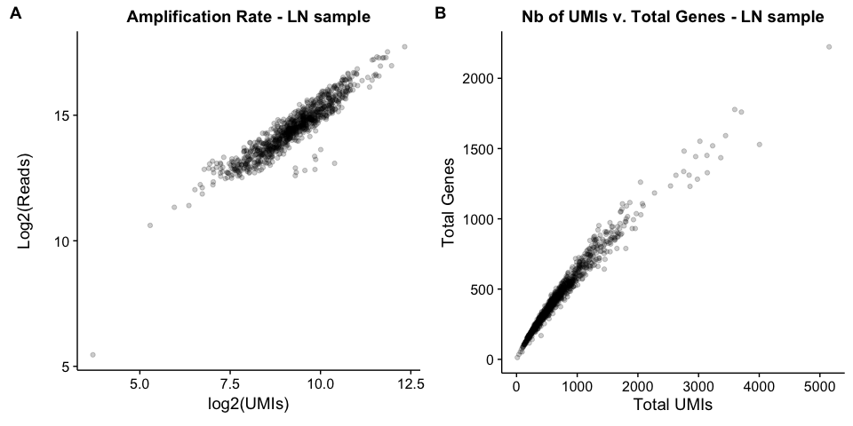

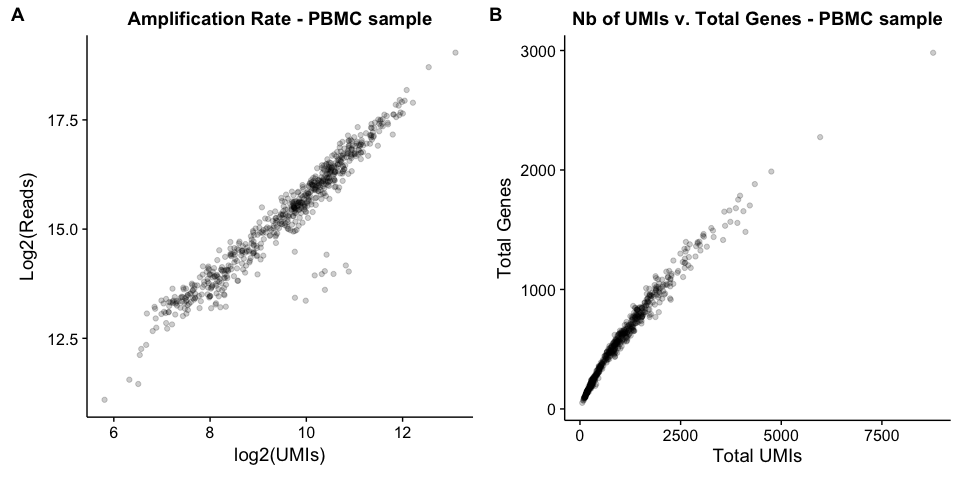

High correlation between nb. of reads and nb. of UMIs observed - there is not such a big amplification biais (*One outlier in LN sample*). It also exhibits a proportional capture efficient here, whereas current platforms (DropSeq, etc.) usually exhibit low and highly variable capture efficiency.

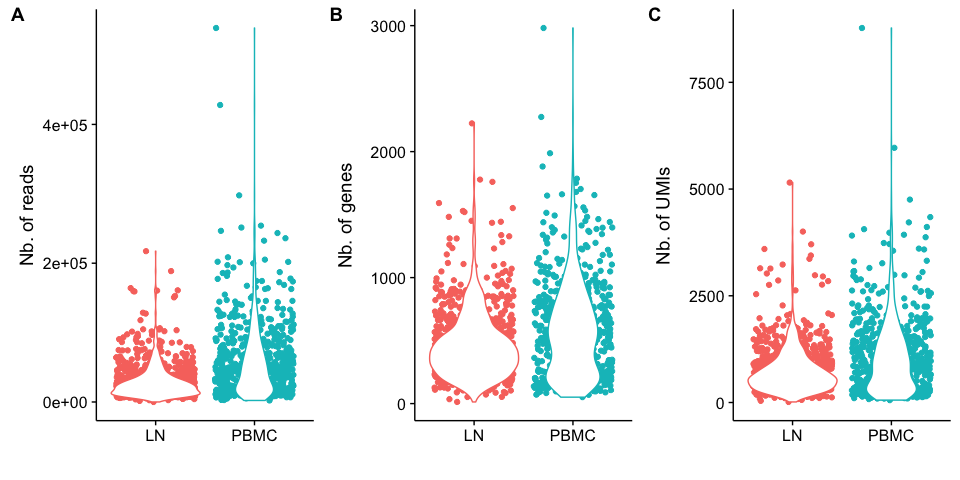

Close nb. of UMIs and detected genes are observed in bith LN and PBMC samples from Live Cells. Some cells with high number of reads are also present (in PBMC sample).